# Discussion 4

Jaideep Bollu

Use the built-in *ChickWeight* data set in R to answer the questions in this discussion assignment.

1. Load the *ChickWeight* data set into your R environment. Open up the help file for this data set. . Describe what the “Description” in the help file says. (1 pt)

```r
data("ChickWeight")
help(ChickWeight)
```

The description says that the ChickWeight data frame has 578 rows and 4 columns from an experiment on the effect of diet on early growth of chicks.

2. Determine the arithmetic mean of weights at `Time = 0`. (1 pt)

```r
Weight_time0 <- subset(ChickWeight, Time == 0)
mean(Weight_time0$weight)
```

```
## [1] 41.06
```

3. Create a data frame named `chick1` that contains all data from Chick 1 from *ChickWeight*. Do the same for Chick 2 and Chick 3, naming them `chick2` and `chick3` respectively. (1.5 pts)

```r
chick1 <- subset(ChickWeight, Chick == 1)
chick2 <- subset(ChickWeight, Chick == 2)
chick3 <- subset(ChickWeight, Chick == 3)
chick1
```

```
##    weight Time Chick Diet
## 1      42    0     1    1
## 2      51    2     1    1
## 3      59    4     1    1
## 4      64    6     1    1
## 5      76    8     1    1
## 6      93   10     1    1
## 7     106   12     1    1
## 8     125   14     1    1
## 9     149   16     1    1
## 10    171   18     1    1
## 11    199   20     1    1
## 12    205   21     1    1
```

```r
chick2
```

```
##    weight Time Chick Diet
## 13     40    0     2    1
## 14     49    2     2    1
## 15     58    4     2    1
## 16     72    6     2    1
## 17     84    8     2    1
## 18    103   10     2    1
## 19    122   12     2    1
## 20    138   14     2    1
## 21    162   16     2    1
## 22    187   18     2    1
## 23    209   20     2    1
## 24    215   21     2    1
```

```r
chick3
```

```
##    weight Time Chick Diet
## 25     43    0     3    1
## 26     39    2     3    1
## 27     55    4     3    1
## 28     67    6     3    1
## 29     84    8     3    1
## 30     99   10     3    1
## 31    115   12     3    1
## 32    138   14     3    1
## 33    163   16     3    1
## 34    187   18     3    1
## 35    198   20     3    1
## 36    202   21     3    1
```

4. Use the `plot` and `lines` commands to create a line plot showing the trajectory of weights (x) across time (y) of the three chicks subsetted from Q3. Make sure to add a title, axis labels, and colors for your line plot. (1.5 pts)

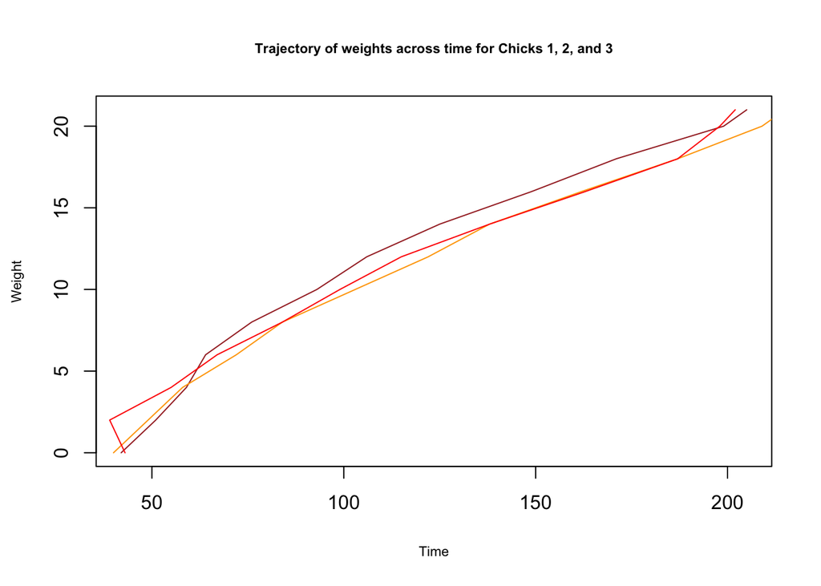

```r
plot(chick1$weight, chick1$Time, type = "l", col = "brown", xlab = "Time", ylab = "Weight", main = "Trajectory of weights across time for Chicks 1, 2, and 3", cex.main = 0.7, cex.lab = 0.7 )
lines(chick2$weight, chick2$Time, col = "orange")
lines(chick3$weight, chick3$Time, col = "red")
```

5. Create a function named `tempConversion` that has two arguments `tempType` and `temp`, which does the following:
- Returns the temperature in Celsius if `tempType` is “F”.
- Returns the temperature in Fahrenheit if `tempType` is “C”.

Make sure to use an if statement in your function. (1.5 pts)

```r
tempConversion <- function(tempType, temp) {
  if (tempType == "F") {
    temp <- (5 / 9 * (temp - 32))
  }

  else if (tempType == "C") {
    temp <- ((temp * 9 / 5) + 32)
  }

  return(temp)
}
```

6. Use the function you created in Q3 to convert these temperatures to Fahrenheit: 0, 32, 22.2, 37. Output the results. (1 pt)

```r
tempConversion("C", 0)
```

```
## [1] 32
```

```r
tempConversion("C", 32)
```

```
## [1] 89.6
```

```r
tempConversion("C", 22.2)
```

```
## [1] 71.96
```

```r
tempConversion("C", 37)
```

```
## [1] 98.6
```